# Assignment 2

Laura Ye

### Exercise 1

One downside of the linear model is that it is sensitive to unusual values because the distance incorporates a squared term. Fit a linear model to the simulated data below, and visualise the results. Rerun a few times to generate different simulated datasets. What do you notice about the model?

#### Solution

First generate and visualize our simulated data.

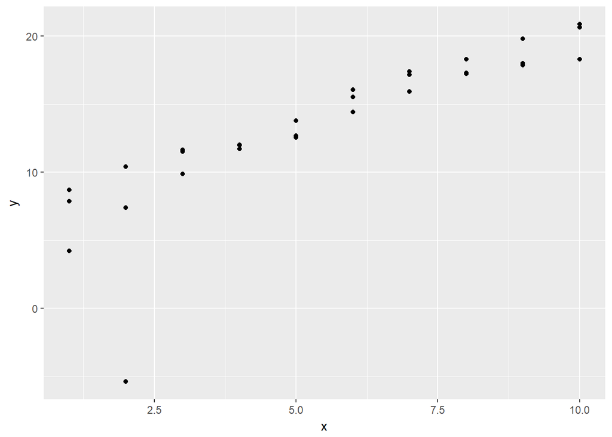

```r
library(tidyverse)
set.seed(620)
sim1a <- tibble(
  x = rep(1:10, each=3),
  y = x * 1.5 + 6 + rt(length(x), df=2)
)

library(ggplot2)
g <- ggplot(sim1a, aes(x=x, y=y)) + geom_point()
g
```

To confirm, we do see an usual data point for x = 2 and y=-5.4.

Next step is to fit a linear model.

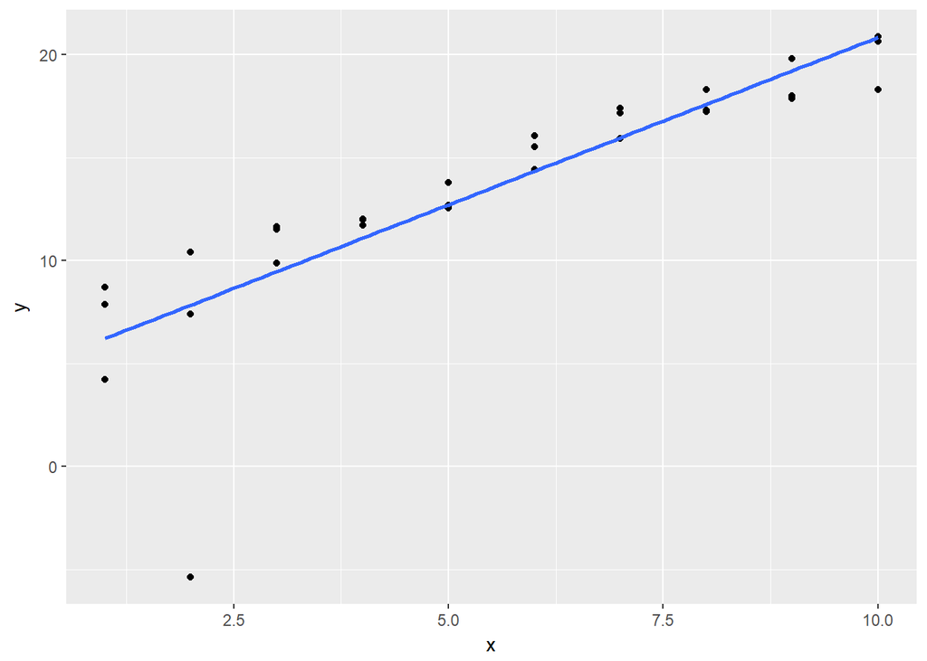

```r
g <- g + stat_smooth(method="lm", se=FALSE)
g
```

Setting different seeds, we can re-generate the simulated data and visualize the fit each time the dataset is re-generated.

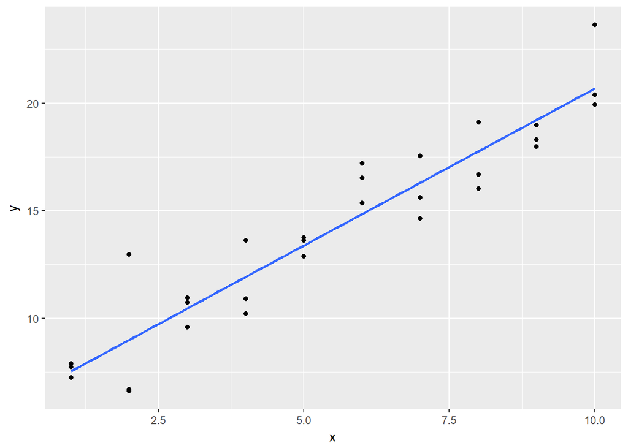

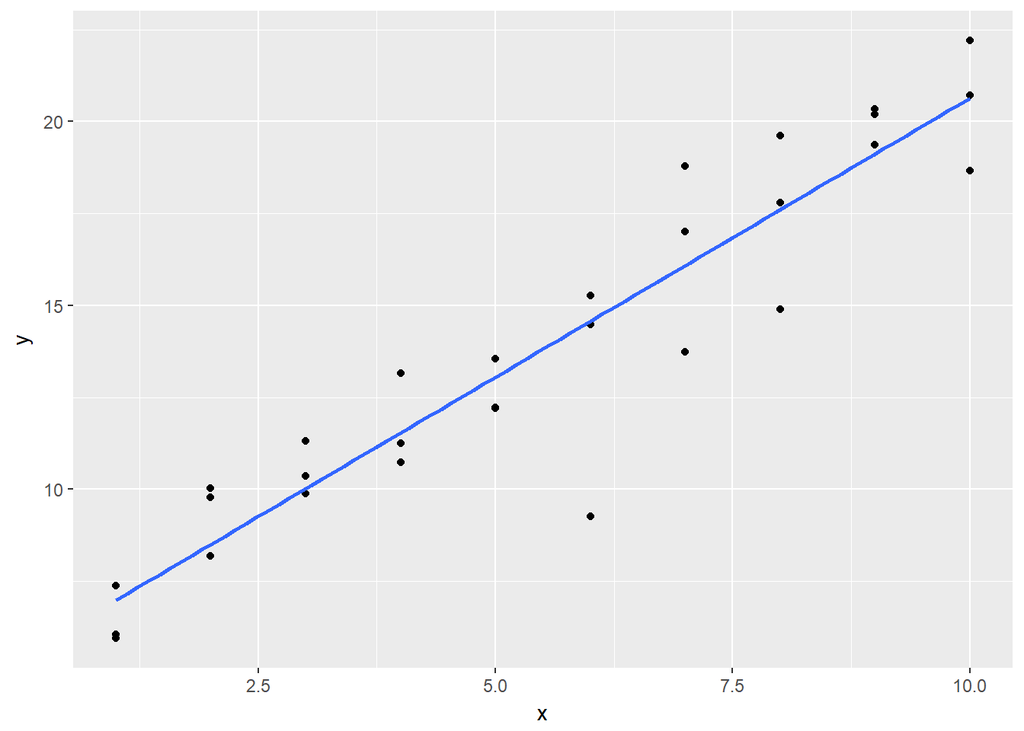

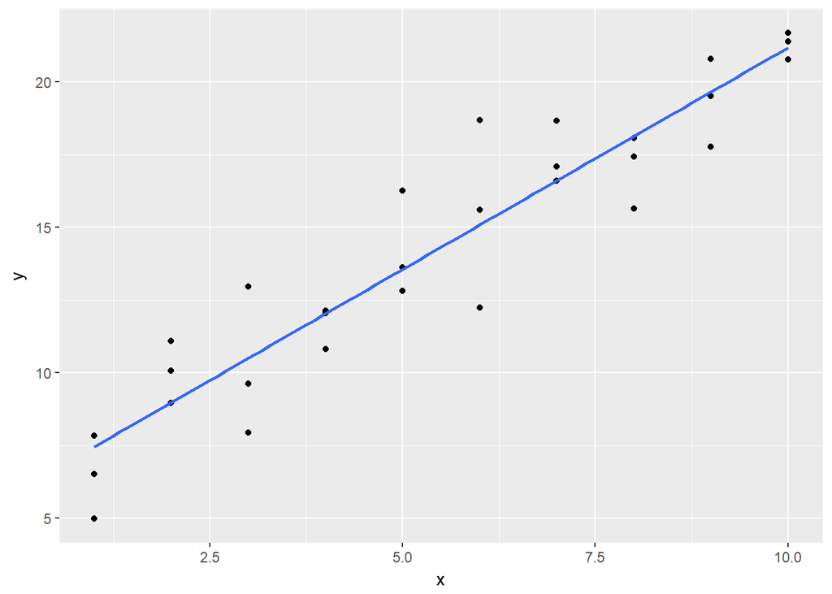

```r
seeds <- c(911, 422, 713)

for (seed in seeds){
  set.seed(seed)
  sim1a_recur <- tibble(
    x = rep(1:10, each=3),
    y = x * 1.5 + 6 + rt(length(x), df=2)
  )
  print(ggplot(sim1a_recur, aes(x=x, y=y)) + geom_point() +
    stat_smooth(method="lm", se=FALSE))
}
```

#### Insights

For each iteration, the linear model still adheres to the main dataset. However, without the outlier, the linear model would be slightly adjusted, most likely in the slope coefficient.

### Exercise 2

One way to make linear models more robust is to use a different distance measure.

For example, instead of root-mean-squared distance, you could use mean-absolute distance:

```r
measure_distance <- function(mod, data) {
  diff <- data$y - predict(mod, data)
  mean(abs(diff))
}
```

Use optim() to fit this model to the simulated data above and compare it to the linear model.

#### Solution

Instead of using this function, I will modify this function as such:

```r
mean.abs.diff <- function(data, par){
  with(data, mean(abs(par[1] + par[2] * x - y)))
}
```

This new function will be fed into `optim` to determine best linear fit.

```r
mod <- optim(par=c(0,1), mean.abs.diff, data=sim1a)
mod
```

```
$par
[1] 6.478517 1.370881

$value
[1] 1.303238

$counts
function gradient
     149       NA

$convergence
[1] 0

$message
NULL
```

We will predict the results from `optim` with the original dataset so we can visualize both fits. Since the result of `optim` is stored as a list, we cannot use `augment` or `predict`.

```r
lm_fit <- lm(y~x, sim1a)

sim1a_optim <- sim1a %>%
  mutate(optim_results = mod$par[1] + mod$par[2]*x) %>%
  mutate(lm_results = lm_fit$coefficients[[1]] + lm_fit$coefficients[[2]]*x)
```

Let’s visualize the two different linear fits.

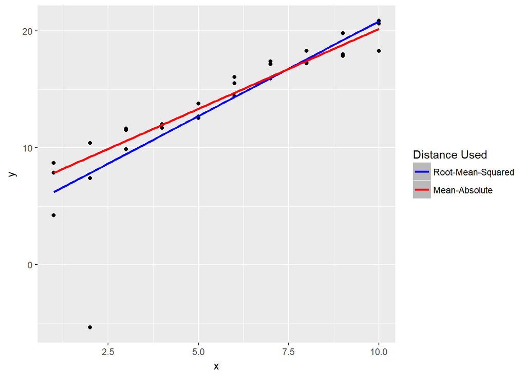

```r
ggplot(sim1a_optim) +
  geom_point(aes(x=x,y=y)) +
  geom_smooth(aes(x=x,y=lm_results, color="blue")) +
  geom_smooth(aes(x=x, y=optim_results, color="red")) +
  labs(color="Distance Used") +
  scale_color_manual(
    labels = c("Root-Mean-Squared", "Mean-Absolute"),
    values=c("blue", "red"))
```

#### Insights

From the simulated data, we can tell that the linear model using mean absolute difference has a lower slope coefficient, and the two linear models intersect around x = 7.5.